# Project 4: Can you predict that?

- Show All Code
- Hide All Code

Course: DS 250

Author

Bethany Ball

## Elevator pitch

This shows housing data and the best ways to find out if a house was built before 1980. It also demests mechine learning, how it works in this context, etc. Overall it demosts a model for mechine learning on how to tell if a house was built before 1980 based on a dataset.

**Read and format project data**

```python
# Include and execute your code here
df = pd.read_csv("https://raw.githubusercontent.com/byuidatascience/data4dwellings/master/data-raw/dwellings_ml/dwellings_ml.csv")
```

## QUESTION|TASK 1

Create 2-3 charts that evaluate potential relationships between the home variables and before1980. Explain what you learn from the charts that could help a machine learning algorithm.

Only one of these charts was very useful at helping find if the house was built before 1980, and that was the ‘Year Built’ chart, witch makes seance. Some of the other charts could help but wouldn’t be that accrate.

```python
#chart one sell price
fig = px.scatter(df, x='before1980', y='sprice', title='Sell Price vs. Year Built', color='before1980',
             color_discrete_map={1: 'blue', 0: 'red'})
fig.update_layout(xaxis_title='Year Built (1: Before 1980, 0: After 1980)', yaxis_title='Sell Price')

#year build v before1980
fig = px.scatter(df, x='before1980', y='yrbuilt', title='Year built vs. before1980')
fig.update_layout(xaxis_title='Before 1980 (1: Yes, 0: No)', yaxis_title='Year Built')
fig.show()

# liveable area v before1980
fig = px.scatter(df, x = 'before1980', y = 'livearea', title = 'Square footage that is liveable v. before1980')
fig.update_layout(xaxis_title = 'Built Before 1980 (1: Yes, 0: No)', yaxis_title = 'Square footage that is liveable')
fig.show()

#deduction in price v yearbuilt
fig = px.scatter(df, x = 'before1980', y = 'deduct', title = 'Deduction from the selling price v. before1980')
fig.update_layout(xaxis_title = 'Built Before 1980 (1: Yes, 0: No)', yaxis_title = 'Deduction from the selling price')
fig.show()
```

[interactive chart not shown]

**Summery/Findings**

- The year the house is build is the best way out of the four that I tested to find out if a house was built before 1980. (go figure)
- ‘Deduction from the selling price’ was okay at finding if a house was built before 1980, but very flewed, it showed that if it was built before 1980 the price was capted at about 20K but after that it capted at 100K, but there is still a lot of overlap.
- ‘Square footage that is liveable’ is very useless. Both the built before 1980s and after are almost identical.
- The ‘Sell Price’ is almost identical to the ‘Deduction from the selling price’, but a little worst, with less above the before 1980s cut-off, witch makes it less usful.

## QUESTION|TASK 2

Build a classification model labeling houses as being built “before 1980” or “during or after 1980”. Your goal is to reach or exceed 90% accuracy. Explain your final model choice (algorithm, tuning parameters, etc) and describe what other models you tried.

I chose to use the RandomForestClassifier for my model. I used it becouse out of the twentey or so models I tried it had the highest accuracy, without overfiting. I also chhose to use a 30/70 for my perameter, this seemed to work the best and is very commonly recoginized a being genreally a good ratio in the inductry.

```python
import pandas as pd
from sklearn.model_selection import train_test_split
from sklearn.naive_bayes import GaussianNB
from sklearn.linear_model import LogisticRegression

from sklearn import metrics
from sklearn.tree import DecisionTreeClassifier
from sklearn.ensemble import RandomForestRegressor

from sklearn.linear_model import LinearRegression
from sklearn.tree import DecisionTreeRegressor

from sklearn.ensemble import RandomForestClassifier
from sklearn.ensemble import GradientBoostingClassifier


# Remove year built, and before 1980 from data to be trained.

# number bedrooms and number of bathrooms

# corr()
# df = df.drop('parcel', axis = 1)
#



# Read the CSV file into a DataFrame
df = pd.read_csv('dwellings_ml.csv')


# Remove the '-' characters from the 'parcel' column
df['parcel'] = df['parcel'].str.replace('-', '')


# Convert the 'parcel' column to integer
df['parcel'] = df['parcel'].astype(int)

df = df.drop('yrbuilt', axis = 1)

df.columns

# Define features and target
features = df.drop('before1980', axis=1)  # Drop the target column
target = df['before1980']

# Split data into training and testing sets
train_data, test_data, train_targets, test_targets = train_test_split(features, target, test_size = .3)


# Instantiate Gaussian Naive Bayes classifier
classifier = RandomForestClassifier()
# classifier = DecisionTreeClassifier()
# classifier = GradientBoostingClassifier()
# classifier = tree(max_depth=10, n_estimators=500)

# Train the classifier
classifier.fit(train_data, train_targets)

# Predict using the trained classifier
targets_predicted = classifier.predict(test_data)

# Calculate accuracy
accuracy = metrics.accuracy_score(test_targets, targets_predicted)
print("Accuracy:", accuracy)
```

```
Accuracy: 0.9519930171661333
```

## QUESTION|TASK 3

Justify your classification model by discussing the most important features selected by your model. This discussion should include a chart and a description of the features.

Acording to my caculations the top five features are as follows:

```
Accuracy: 0.9346814082048298
Top 5 features:
               Feature  Importance
38  arcstyle_ONE-STORY    0.271366
0               parcel    0.261210
23           quality_C    0.146098
26         gartype_Att    0.053398
1             abstrprd    0.052640
```

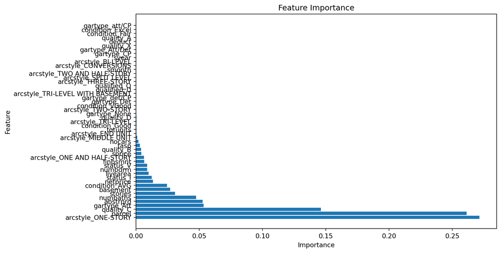

```python
#%%
import pandas as pd
from sklearn.model_selection import train_test_split
from sklearn.naive_bayes import GaussianNB
from sklearn.linear_model import LogisticRegression

from sklearn import metrics
from sklearn.tree import DecisionTreeClassifier

from sklearn.tree import DecisionTreeRegressor

from sklearn.ensemble import RandomForestClassifier
from sklearn.ensemble import GradientBoostingClassifier

#%%
# Remove year built, and before 1980 from data to be trained.

# number bedrooms and number of bathrooms

# corr()
# df = df.drop('parcel', axis = 1)
#


#%%
# Read the CSV file into a DataFrame
df = pd.read_csv('dwellings_ml.csv')

#%%
# Remove the '-' characters from the 'parcel' column
df['parcel'] = df['parcel'].str.replace('-', '')

#%%
# Convert the 'parcel' column to integer
df['parcel'] = df['parcel'].astype(int)



#%%

df = df.drop('yrbuilt', axis = 1)

df.columns

#%%
# Define features and target
features = df.drop('before1980', axis=1)  # Drop the target column
target = df['before1980']

# Split data into training and testing sets
train_data, test_data, train_targets, test_targets = train_test_split(features, target, test_size = .3)


# Instantiate Gaussian Naive Bayes classifier
classifier = GradientBoostingClassifier()
# classifier = tree(max_depth=10, n_estimators=500)

# Train the classifier
classifier.fit(train_data, train_targets)

# Predict using the trained classifier
targets_predicted = classifier.predict(test_data)

# Calculate accuracy
accuracy = metrics.accuracy_score(test_targets, targets_predicted)
print("Accuracy:", accuracy)



#%%

import matplotlib.pyplot as plt

# Get feature importances
feature_importances = classifier.feature_importances_

# Get the names of the features
feature_names = features.columns

# Create a DataFrame to hold feature names and their importances
feature_importance_df = pd.DataFrame({
    'Feature': feature_names,
    'Importance': feature_importances
})

# Sort the DataFrame by importance
feature_importance_df = feature_importance_df.sort_values(by='Importance', ascending=False)

# Plotting the feature importance
plt.figure(figsize=(10, 6))
plt.barh(feature_importance_df['Feature'], feature_importance_df['Importance'])
plt.xlabel('Importance')
plt.ylabel('Feature')
plt.title('Feature Importance')
plt.show()

# Display top 5 features
print("Top 5 features:")
print(feature_importance_df.head())
```

## QUESTION|TASK 4

Describe the quality of your classification model using 2-3 different evaluation metrics. You also need to explain how to interpret each of the evaluation metrics you use.

My metrics are as follows:

Accuracy: Accuracy measures the proportion of correctly classified instances out of the total instances. It is calculated as the ratio of the number of correct predictions to the total number of predictions. Interpretation: An accuracy of 90% means that 90% of the predictions made by the model are correct. However, accuracy alone might not provide a complete picture of the model’s performance, especially in imbalanced datasets where one class dominates the other.

```
- This model is very accurate at about 93-95%%.
```

Precision and Recall: Precision and recall are metrics often used together, especially in binary classification tasks.

[output not shown]

Back to top